# framingham

Sarah Lotspeich

2024-08-16

```r
# Load packages
library(riskCommunicator) ## for the Framingham teaching data
library(tableone) ## for Table 1
library(ggplot2) ## for pretty plots
library(speedyCMI) ## for parametric imputation methods
library(imputeCensRd) ## for semiparametric imputation method
```

## Data

```r
# Load the data
data(framingham)
length(unique(framingham$RANDID)) ## 4434 patients
```

```
## [1] 4434
```

There are 4434 patients in the Framingham teaching dataset.

```r
to_exclude = framingham |>
  dplyr::group_by(RANDID) |>
  dplyr::filter(AGE == min(AGE), ## subset to first visits,
                PREVHYP == 1) |> ## and patients with hypertension at first visit
  dplyr::pull(RANDID) ## create a vector of their IDs
length(to_exclude) # 1430 patients excluded for prevalent hypertension
```

```
## [1] 1430
```

We excluded 1430 patients who had prevalent hypertension at their first visit in the Framingham Study. We then subsetted the data for the remaining patients to include only visits leading up to and including a hypertension diagnosis (or end of followup).

```r
to_analyze = framingham |>
  dplyr::filter(!(RANDID %in% to_exclude), ## exclude patients with prevalence hypertension (at baseline)
                TIME <= TIMEHYP) ## subset to visits up to and including hypertension diagnosis
```

The analysis data included each patient’s first and last visits (either hypertension diagnosis or end of followup), keeping their `SYSBP`, `SEX`, `AGE`, `BMI`, and `TIMEHYP` from each.

```r
to_analyze_first = to_analyze |>
  dplyr::group_by(RANDID) |>
  dplyr::filter(AGE == min(AGE)) |>
  dplyr::rename(SYSBP0 = SYSBP,
                AGE0 = AGE,
                BMI0 = BMI) |>
  dplyr::select(RANDID, SEX, AGE0, BMI0, SYSBP0, TIMEHYP) |>
  dplyr::mutate(TIMEHYP = TIMEHYP / 365, ## convert time from days --> years
                SEX = factor(x = SEX,
                             levels = c(1, 2),
                             labels = c("MALE", "FEMALE"))
                )

to_analyze_last = to_analyze |>
  dplyr::group_by(RANDID) |>
  dplyr::filter(AGE == max(AGE)) |>
  dplyr::rename(SYSBP1 = SYSBP,
                AGE1 = AGE,
                BMI1 = BMI) |>
  dplyr::select(RANDID, AGE1, BMI1, SYSBP1, HYPERTEN)

to_analyze = to_analyze_first |>
  dplyr::left_join(to_analyze_last) |>
  dplyr::mutate(SYSBP_CHANGE = SYSBP0 - SYSBP1)
```

We excluded 779 patients who had only one visit before hypertension diagnosis or end of followup.

```r
to_analyze = to_analyze |>
  dplyr::filter(AGE0 != AGE1) ## subset to patients with at least two visits
nrow(to_analyze) # 2225 patients
```

```
## [1] 2225
```

Finally, we excluded 7 patients who were missing `BMI` at their first visit.

```r
to_analyze = to_analyze |>
  dplyr::filter(!is.na(BMI0)) ## subset to patients with non-missing BMI
nrow(to_analyze) # 2218 patients
```

```
## [1] 2218
```

These exclusions left a sample of 2218 patients for the analysis of change in systolic blood pressure.

## Exploratory Data Analysis

Patients with and without hypertension are described below. From this table, we observe the following:

- There was a higher proportion of women with hypertension, but a lower proportion of men.
- On average, patients diagnosed with hypertension tended to be older (by about $2$ years) than those who were not diagnosed.
- On average, patients diagnosed with hypertension tended to have higher BMIs (by about $1$ point) than those who were not diagnosed.
- On average, patients diagnosed with hypertension tended to have higher systolic blood pressures at both their first and last visits than those who were not diagnosed.

```
##                     Stratified by HYPERTEN
##                      level  0              1              p      test
##   n                          1,007          1,211
##   SEX (%)            MALE      447 (44.4)     496 (41.0)   0.113
##                      FEMALE    560 (55.6)     715 (59.0)
##   AGE0 (mean (SD))           46.19 (7.71)   48.02 (8.23)  <0.001
##   BMI0 (mean (SD))           24.20 (3.20)   25.14 (3.45)  <0.001
##   SYSBP0 (mean (SD))        115.04 (10.15) 122.53 (10.55) <0.001
##   SYSBP1 (mean (SD))        119.08 (11.11) 134.99 (13.56) <0.001
```

The relationship between systolic blood pressure at first and last visits was positive among patients diagnosed with hypertension or undiagnosed. However, patients diagnosed with hypertension consistently had higher followup systolic blood pressure than patients not diagnosed across all baseline values.

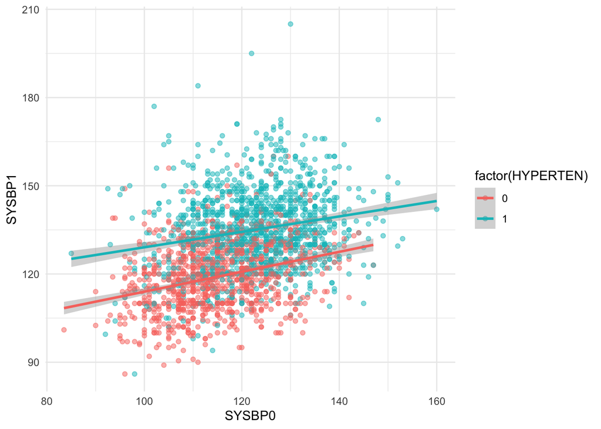

```r
to_analyze |>
  ggplot(aes(x = SYSBP0, y = SYSBP1, color = factor(HYPERTEN))) +
  geom_point(alpha = 0.5) +
  geom_smooth(method = "lm") +
  theme_minimal()
```

## Imputation Model Selection

```r
### Function to make density plot of the distribution of TIMEHYP by diagnosis
density_plot = function(imp_fit, title) {
  imp_fit$imputed_data |>
    dplyr::mutate(HYPERTEN = factor(x = HYPERTEN,
                                    levels = c(1, 0),
                                    labels = c("Diagnosed\n(Uncensored)", "Undiagnosed\n(Censored)"))) |>
    ggplot(aes(x = imp, fill = HYPERTEN)) +
    geom_density(alpha = 0.7) +
    geom_vline(xintercept = 25, linetype = 2) +
    ggthemes::scale_fill_colorblind(name = "Patient\nStatus:") +
    theme_minimal() +
    theme(legend.position = "right") +
    xlab("Time to Hypertension Diagnosis\n(Observed or Imputed)") +
    ylab("Density") +
    ggtitle(title) +
    xlim(c(0, 160))
}
```

### (i) Weibull Distribution

```r
## (1) Weibull
weib_imp = cmi_fp_analytical(imputation_model = Surv(time = TIMEHYP, event = HYPERTEN) ~ SEX + AGE0 + BMI0 + SYSBP0,
                             dist = "weibull",
                             data = to_analyze)
### Parameters of the fitted model
weib_params = c(weib_imp$coefficients, weib_imp$scale)
weib_params
```

```
## (Intercept)   SEXFEMALE        AGE0        BMI0      SYSBP0
##  7.46100049 -0.09095971 -0.01178978 -0.01860167 -0.02672163  0.50462815
```

```r
### AIC for the fitted model
weib_aic = weib_imp$aic
weib_aic
```

```
## [1] 9832.102
```

```r
### BIC for the fitted model
weib_bic = weib_imp$bic
weib_bic
```

```
## [1] 9866.328
```

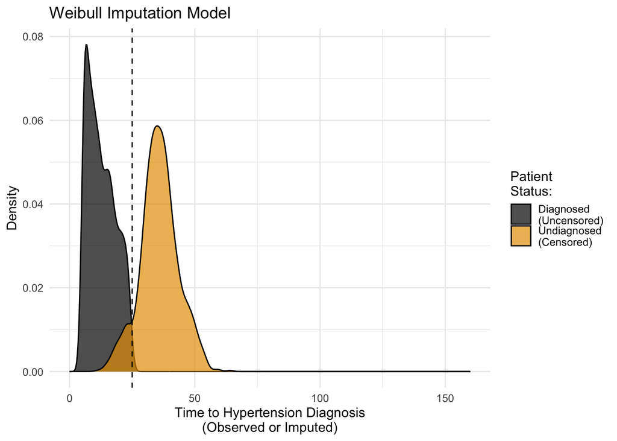

```r
### Density plot of the distribution of TIMEHYP
weib_plot = weib_imp |>
  density_plot(title = "Weibull Imputation Model")
weib_plot
```

### (ii) Exponential Distribution

```r
## (2) Exponential
expo_imp = cmi_fp_analytical(imputation_model = Surv(time = TIMEHYP, event = HYPERTEN) ~ SEX + AGE0 + BMI0 + SYSBP0,
                             dist = "exponential",
                             data = to_analyze)
### Parameters of the fitted model
expo_params = c(expo_imp$coefficients, expo_imp$scale)
expo_params
```

```
## (Intercept)   SEXFEMALE        AGE0        BMI0      SYSBP0
##  9.97077329 -0.15841723 -0.01480131 -0.03225020 -0.04126827  1.00000000
```

```r
### AIC for the fitted model
expo_aic = expo_imp$aic
expo_aic
```

```
## [1] 10422.87
```

```r
### BIC for the fitted model
expo_bic = expo_imp$bic
expo_bic
```

```
## [1] 10451.39
```

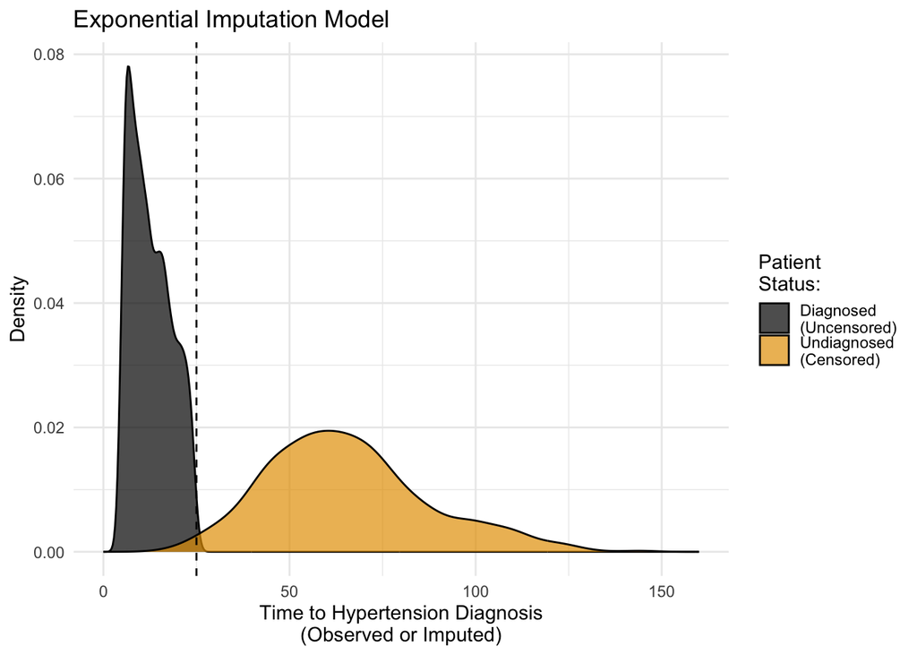

```r
### Density plot of the distribution of TIMEHYP
expo_plot = expo_imp |>
  density_plot(title = "Exponential Imputation Model")
expo_plot
```

### (iii) Log-Normal Distribution

```r
## (3) Log-normal
lognorm_imp = cmi_fp_analytical(imputation_model = Surv(time = TIMEHYP, event = HYPERTEN) ~ SEX + AGE0 + BMI0 + SYSBP0,
                                dist = "lognormal",
                                data = to_analyze)
### Parameters of the fitted model
lognorm_params = c(lognorm_imp$coefficients, lognorm_imp$scale)
lognorm_params
```

```
## (Intercept)   SEXFEMALE        AGE0        BMI0      SYSBP0
##  7.42660949 -0.08654891 -0.01165918 -0.02696793 -0.02667391  0.65481311
```

```r
### AIC for the fitted model
lognorm_aic = lognorm_imp$aic
lognorm_aic
```

```
## [1] 9678.568
```

```r
### BIC for the fitted model
lognorm_bic = lognorm_imp$bic
lognorm_bic
```

```
## [1] 9712.794
```

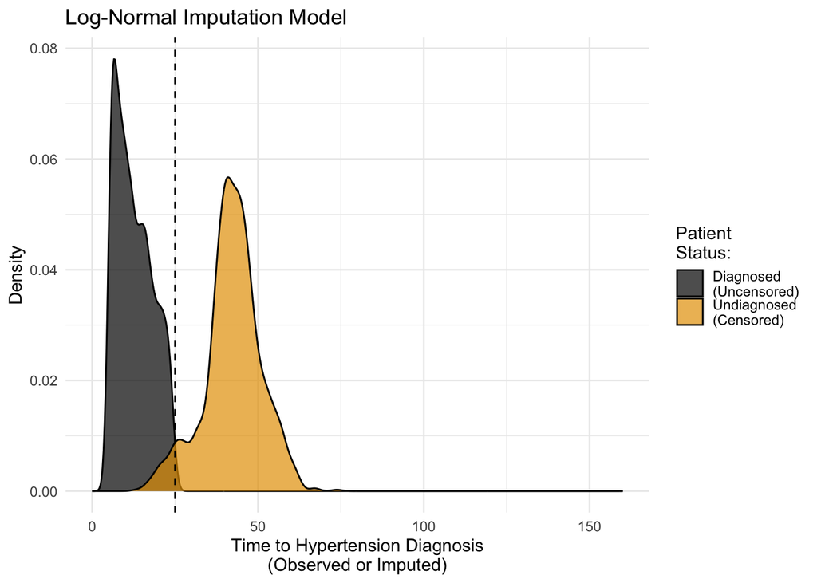

```r
### Density plot of the distribution of TIMEHYP
lognorm_plot = lognorm_imp |>
  density_plot(title = "Log-Normal Imputation Model")
lognorm_plot
```

```r
### Median time to hypertension (imputed)
median(lognorm_imp$imputed_data$imp[lognorm_imp$imputed_data$HYPERTEN == 0])
```

```
## [1] 42.52165
```

### (iv) Log-Logistic Distribution

```r
## (4) Log-logistic
loglog_imp = cmi_fp_analytical(imputation_model = Surv(time = TIMEHYP, event = HYPERTEN) ~ SEX + AGE0 + BMI0 + SYSBP0,
                               dist = "loglogistic",
                               data = to_analyze)
### Parameters of the fitted model
loglog_params = c(loglog_imp$coefficients, loglog_imp$scale)
loglog_params
```

```
## (Intercept)   SEXFEMALE        AGE0        BMI0      SYSBP0
##  7.63025337 -0.08923875 -0.01225758 -0.02663284 -0.02824150  0.38386544
```

```r
### AIC for the fitted model
loglog_aic = loglog_imp$aic
loglog_aic
```

```
## [1] 9720.943
```

```r
### BIC for the fitted model
loglog_bic = loglog_imp$bic
loglog_bic
```

```
## [1] 9755.169
```

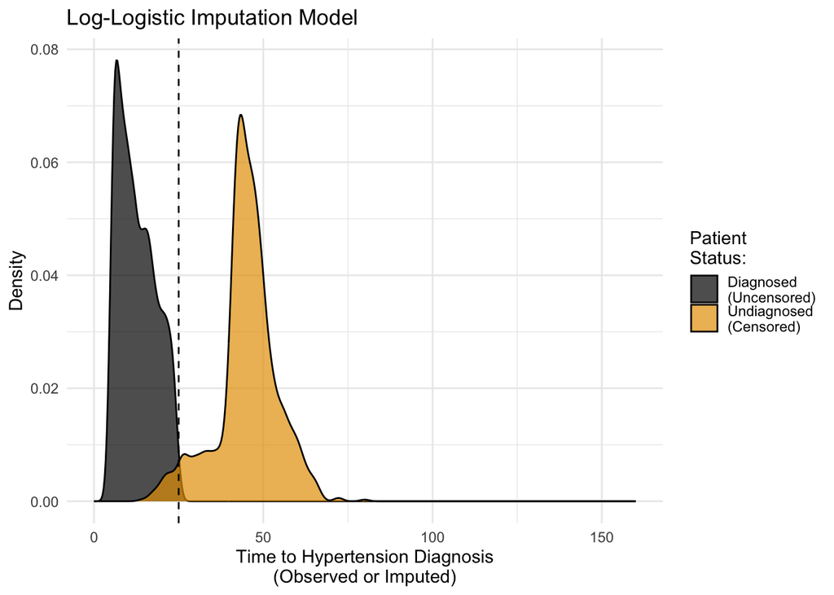

```r
### Density plot of the distribution of TIMEHYP
loglog_plot = loglog_imp |>
  density_plot(title = "Log-Logistic Imputation Model")
loglog_plot
```

### (v) Piecewise Exponential Distribution

```r
## (5) Piecewise exponential
to_analyze = to_analyze |>
  dplyr::mutate(FEMALE = as.numeric(SEX == "FEMALE"))
pwe_imp = cmi_fp_analytical(imputation_model = Surv(time = TIMEHYP, event = HYPERTEN) ~ FEMALE + AGE0 + BMI0 + SYSBP0,
                            dist = "pwe",
                            data = to_analyze,
                            nintervals = 10)
### Parameters of the fitted model
pwe_params = c(pwe_imp$coefficients, pwe_imp$blhaz)
pwe_params
```

```
##       FEMALE         AGE0         BMI0       SYSBP0
## 1.778168e-01 2.113435e-02 3.714363e-02 5.061556e-02 2.416849e-06 9.256614e-06
##
## 4.877157e-05 1.075072e-05 1.171967e-05 1.307002e-05 1.528954e-05 1.611556e-05
##
## 1.549125e-05 1.815138e-05
```

```r
### AIC for the fitted model
pwe_aic = pwe_imp$aic
pwe_aic
```

```
## [1] 9734.242
```

```r
### BIC for the fitted model
pwe_bic = pwe_imp$bic
pwe_bic
```

```
## [1] 9814.103
```

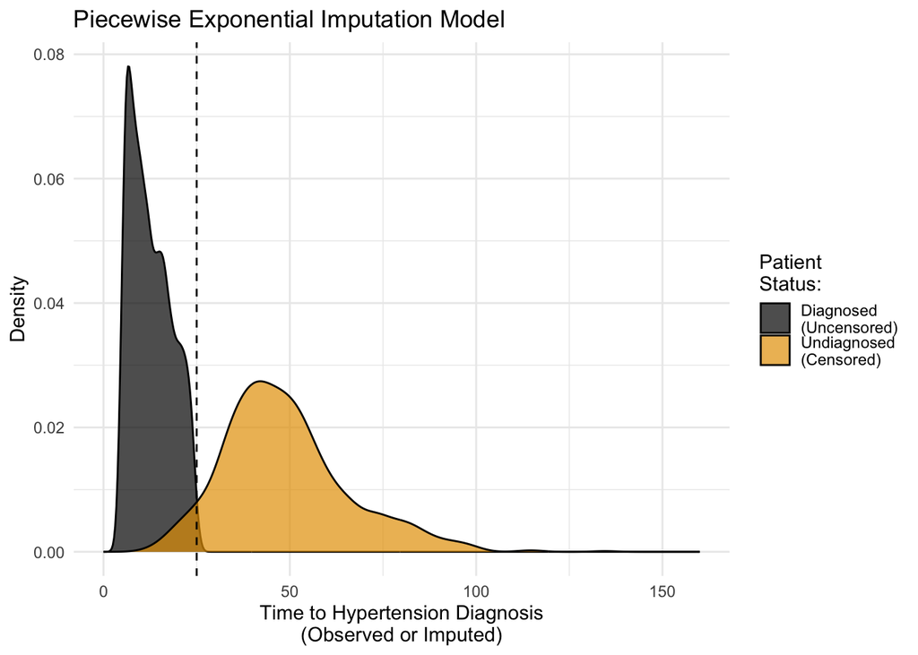

```r
### Density plot of the distribution of TIMEHYP
pwe_plot = pwe_imp |>
  density_plot(title = paste("Piecewise Exponential Imputation Model"))
pwe_plot
```

### Comparing Model Fits

```r
data.frame(Distribution = c("Exponential", "Log-Logistic",
                            "Log-Normal", "Piecewise Exponential",
                            "Weibull"),
           MeanTIME = c(mean(expo_imp$imputed_data$imp),
                        mean(loglog_imp$imputed_data$imp),
                        mean(lognorm_imp$imputed_data$imp),
                        mean(pwe_imp$imputed_data$imp),
                        mean(weib_imp$imputed_data$imp)),
           MedianTIME = c(median(expo_imp$imputed_data$imp),
                          median(loglog_imp$imputed_data$imp),
                          median(lognorm_imp$imputed_data$imp),
                          median(pwe_imp$imputed_data$imp),
                          median(weib_imp$imputed_data$imp)),
           AIC = c(expo_aic, loglog_aic, lognorm_aic, pwe_aic, weib_aic),
           BIC = c(expo_bic, loglog_bic, lognorm_bic, pwe_bic, weib_bic)) |>
  kableExtra::kable(format = "html") |>
  kableExtra::kable_styling()
```

| Distribution | MeanTIME | MedianTIME | AIC | BIC |
| --- | --- | --- | --- | --- |
| Exponential | 36.78676 | 21.67534 | 10422.867 | 10451.389 |
| Log-Logistic | 27.41109 | 21.22603 | 9720.943 | 9755.169 |
| Log-Normal | 26.17382 | 21.12877 | 9678.568 | 9712.794 |
| Piecewise Exponential | 29.12218 | 20.95753 | 9734.242 | 9814.103 |
| Weibull | 23.21192 | 20.60179 | 9832.102 | 9866.328 |

### Comparing Imputed Values

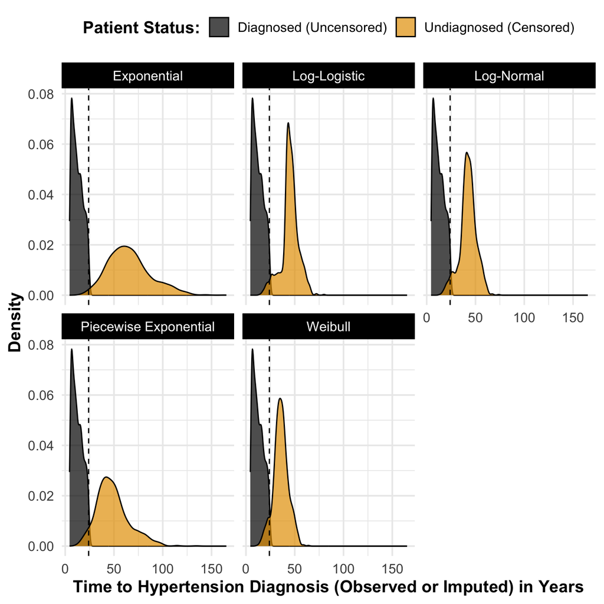